# Titanic Visualization

In this document, I will explain the steps taken to create a graphical visualizaiton of the famous Titanic

### Graph 1

The first graph is a visualization of all of the passengers aboard the titanic. The graph displays each passenger related to thier age, how much they paid, and their gender. Because there is only one plot, there is no need for facets or more than one layer

```
##
## > require("jsonlite")
```

```
##
## > require("RCurl")
```

```
##
## > require("ggplot2")
```

```
##
## > df <- data.frame(fromJSON(getURL(URLencode("129.152.144.84:5001/rest/native/?query=\"select * from titanic \""),
## +     httpheader = c(DB = "jdbc:or ..." ... [TRUNCATED]
##
## > summary(df)
##                                       PASSENGERID  SURVIVED    PCLASS
##  </pre></body></html>Xtext/csvUUTF-8(?N`vPJS:  1   0   :549   1   :216
##  1                                          :  1   1   :342   2   :184
##  10                                         :  1   null:  2   3   :491
##  100                                        :  1              null:  2
##  101                                        :  1
##  102                                        :  1
##  (Other)                                    :887
##                                     NAME         SEX           AGE
##  null                                 :  2   female:314   null   :179
##  Abbing, Mr. Anthony                  :  1   male  :577   24     : 30
##  Abbott, Mr. Rossmore Edward          :  1   null  :  2   22     : 27
##  Abbott, Mrs. Stanton (Rosa Hunt)     :  1                18     : 26
##  Abelson, Mr. Samuel                  :  1                19     : 25
##  Abelson, Mrs. Samuel (Hannah Wizosky):  1                28     : 25
##  (Other)                              :886                (Other):581
##      SIBSP         PARCH          TICKET                  FARE
##  0      :608   0      :678   1601    :  7   8.05000019073486: 43
##  1      :209   1      :118   347082  :  7   13              : 42
##  2      : 28   2      : 80   CA. 2343:  7   7.89580011367798: 38
##  4      : 18   3      :  5   3101295 :  6   7.75            : 34
##  3      : 16   5      :  5   347088  :  6   26              : 31
##  8      :  7   4      :  4   CA 2144 :  6   10.5            : 24
##  (Other):  7   (Other):  3   (Other) :854   (Other)         :681
##          CABIN     EMBARKED
##  null       :689   C   :168
##  B96 B98    :  4   null:  4
##  C23 C25 C27:  4   Q   : 77
##  G6         :  4   S   :644
##  C22 C26    :  3
##  D          :  3
##  (Other)    :186
##
## > head(df)
##   PASSENGERID SURVIVED PCLASS                                  NAME    SEX
## 1         311        1      1        Hays, Miss. Margaret Bechstein female
## 2         312        1      1            Ryerson, Miss. Emily Borie female
## 3         313        0      2 Lahtinen, Mrs. William (Anna Sylfven) female
## 4         314        0      3                Hendekovic, Mr. Ignjac   male
## 5         315        0      2                    Hart, Mr. Benjamin   male
## 6         316        1      3       Nilsson, Miss. Helmina Josefina female
##   AGE SIBSP PARCH       TICKET             FARE           CABIN EMBARKED
## 1  24     0     0        11767 83.1583023071289             C54        C
## 2  18     2     2     PC 17608          262.375 B57 B59 B63 B66        C
## 3  26     1     1       250651               26            null        S
## 4  28     0     0       349243 7.89580011367798            null        S
## 5  43     1     1 F.C.C. 13529            26.25            null        S
## 6  26     0     0       347470 7.85419988632202            null        S
##
## > require(extrafont)
```

```
## Registering fonts with R
```

```
##
## > ggplot() + coord_cartesian() + scale_x_continuous() +
## +     scale_y_continuous() + labs(title = "Titanic") + labs(x = "Age",
## +     y = paste("Fare ..." ... [TRUNCATED]
```

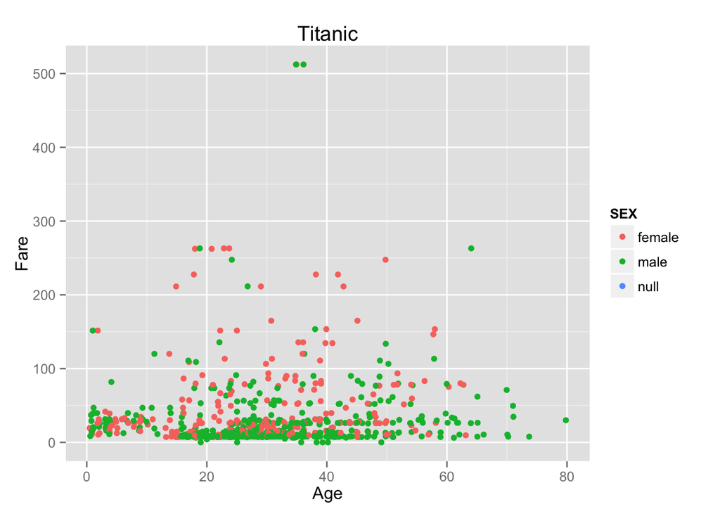

```r
source("../02 Visualizations/Graph 1.R", echo = TRUE)
```

### Graph 2

The second graph is the same as the first, but in the sql statement I removed any data where the sex is a null value. The graph shows the large proportion of cheap tickets bought by men, generally between the ages of 20 and 40.

```
##
## > require("jsonlite")
##
## > require("RCurl")
##
## > require("ggplot2")
##
## > df <- data.frame(fromJSON(getURL(URLencode("129.152.144.84:5001/rest/native/?query=\"select * from titanic where SEX is NOT NULL\""),
## +     httphea .... [TRUNCATED]
##
## > summary(df)
##   PASSENGERID       SURVIVED          PCLASS
##  Min.   :  1.0   Min.   :0.0000   Min.   :1.000
##  1st Qu.:223.5   1st Qu.:0.0000   1st Qu.:2.000
##  Median :446.0   Median :0.0000   Median :3.000
##  Mean   :446.0   Mean   :0.3838   Mean   :2.309
##  3rd Qu.:668.5   3rd Qu.:1.0000   3rd Qu.:3.000
##  Max.   :891.0   Max.   :1.0000   Max.   :3.000
##
##                                     NAME         SEX           AGE
##  Abbing, Mr. Anthony                  :  1   female:314   null   :177
##  Abbott, Mr. Rossmore Edward          :  1   male  :577   24     : 30
##  Abbott, Mrs. Stanton (Rosa Hunt)     :  1                22     : 27
##  Abelson, Mr. Samuel                  :  1                18     : 26
##  Abelson, Mrs. Samuel (Hannah Wizosky):  1                19     : 25
##  Adahl, Mr. Mauritz Nils Martin       :  1                28     : 25
##  (Other)                              :885                (Other):581
##      SIBSP           PARCH             TICKET         FARE
##  Min.   :0.000   Min.   :0.0000   1601    :  7   Min.   :  0.00
##  1st Qu.:0.000   1st Qu.:0.0000   347082  :  7   1st Qu.:  7.91
##  Median :0.000   Median :0.0000   CA. 2343:  7   Median : 14.45
##  Mean   :0.523   Mean   :0.3816   3101295 :  6   Mean   : 32.20
##  3rd Qu.:1.000   3rd Qu.:0.0000   347088  :  6   3rd Qu.: 31.00
##  Max.   :8.000   Max.   :6.0000   CA 2144 :  6   Max.   :512.33
##                                   (Other) :852
##          CABIN     EMBARKED
##  null       :687   C   :168
##  B96 B98    :  4   null:  2
##  C23 C25 C27:  4   Q   : 77
##  G6         :  4   S   :644
```

[output cut: 10 more lines]

```
## 5         315        0      2                    Hart, Mr. Benjamin   male
## 6         316        1      3       Nilsson, Miss. Helmina Josefina female
##   AGE SIBSP PARCH       TICKET     FARE           CABIN EMBARKED
## 1  24     0     0        11767  83.1583             C54        C
## 2  18     2     2     PC 17608 262.3750 B57 B59 B63 B66        C
## 3  26     1     1       250651  26.0000            null        S
## 4  28     0     0       349243   7.8958            null        S
## 5  43     1     1 F.C.C. 13529  26.2500            null        S
## 6  26     0     0       347470   7.8542            null        S
##
## > require(extrafont)
##
## > ggplot() + coord_cartesian() + scale_x_continuous() +
## +     scale_y_continuous() + labs(title = "Titanic") + labs(x = "Age",
## +     y = paste("Fare ..." ... [TRUNCATED]
```

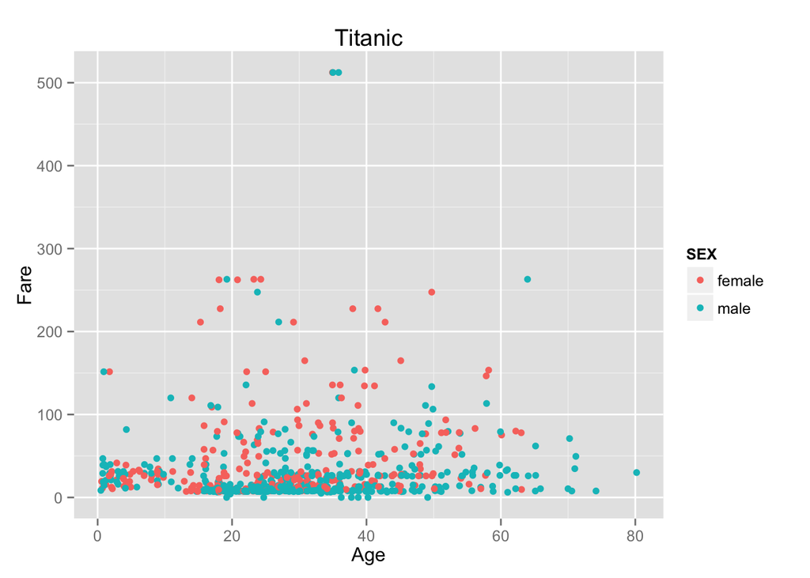

```r
source("../02 Visualizations/Graph 2.R", echo = TRUE)
```

### Graph 3

The third graph visualizes the relationship between those who survived and their wealth/gender. In this graph it was necessary to change the key, in the layer statement after color, from SEX to SURVIVED, but because survival is not a continous variable I had to change add an extra statement to convert it. It is clear that women were much more likely to survive and men who paid a high fare.

```
##
## > require("jsonlite")
##
## > require("RCurl")
##
## > require("ggplot2")
##
## > df <- data.frame(fromJSON(getURL(URLencode("129.152.144.84:5001/rest/native/?query=\"select * from titanic where SEX is NOT NULL\""),
## +     httphea .... [TRUNCATED]
##
## > summary(df)
##   PASSENGERID       SURVIVED          PCLASS
##  Min.   :  1.0   Min.   :0.0000   Min.   :1.000
##  1st Qu.:223.5   1st Qu.:0.0000   1st Qu.:2.000
##  Median :446.0   Median :0.0000   Median :3.000
##  Mean   :446.0   Mean   :0.3838   Mean   :2.309
##  3rd Qu.:668.5   3rd Qu.:1.0000   3rd Qu.:3.000
##  Max.   :891.0   Max.   :1.0000   Max.   :3.000
##
##                                     NAME         SEX           AGE
##  Abbing, Mr. Anthony                  :  1   female:314   null   :177
##  Abbott, Mr. Rossmore Edward          :  1   male  :577   24     : 30
##  Abbott, Mrs. Stanton (Rosa Hunt)     :  1                22     : 27
##  Abelson, Mr. Samuel                  :  1                18     : 26
##  Abelson, Mrs. Samuel (Hannah Wizosky):  1                19     : 25
##  Adahl, Mr. Mauritz Nils Martin       :  1                28     : 25
##  (Other)                              :885                (Other):581
##      SIBSP           PARCH             TICKET         FARE
##  Min.   :0.000   Min.   :0.0000   1601    :  7   Min.   :  0.00
##  1st Qu.:0.000   1st Qu.:0.0000   347082  :  7   1st Qu.:  7.91
##  Median :0.000   Median :0.0000   CA. 2343:  7   Median : 14.45
##  Mean   :0.523   Mean   :0.3816   3101295 :  6   Mean   : 32.20
##  3rd Qu.:1.000   3rd Qu.:0.0000   347088  :  6   3rd Qu.: 31.00
##  Max.   :8.000   Max.   :6.0000   CA 2144 :  6   Max.   :512.33
##                                   (Other) :852
##          CABIN     EMBARKED
##  null       :687   C   :168
##  B96 B98    :  4   null:  2
##  C23 C25 C27:  4   Q   : 77
##  G6         :  4   S   :644
```

[output cut: 8 more lines]

```
## 3         313        0      2 Lahtinen, Mrs. William (Anna Sylfven) female
## 4         314        0      3                Hendekovic, Mr. Ignjac   male
## 5         315        0      2                    Hart, Mr. Benjamin   male
## 6         316        1      3       Nilsson, Miss. Helmina Josefina female
##   AGE SIBSP PARCH       TICKET     FARE           CABIN EMBARKED
## 1  24     0     0        11767  83.1583             C54        C
## 2  18     2     2     PC 17608 262.3750 B57 B59 B63 B66        C
## 3  26     1     1       250651  26.0000            null        S
## 4  28     0     0       349243   7.8958            null        S
## 5  43     1     1 F.C.C. 13529  26.2500            null        S
## 6  26     0     0       347470   7.8542            null        S
##
## > ggplot() + coord_cartesian() + scale_x_discrete() +
## +     scale_y_continuous() + labs(title = "Titanic") + labs(x = "SURVIVED",
## +     y = paste("F ..." ... [TRUNCATED]
```

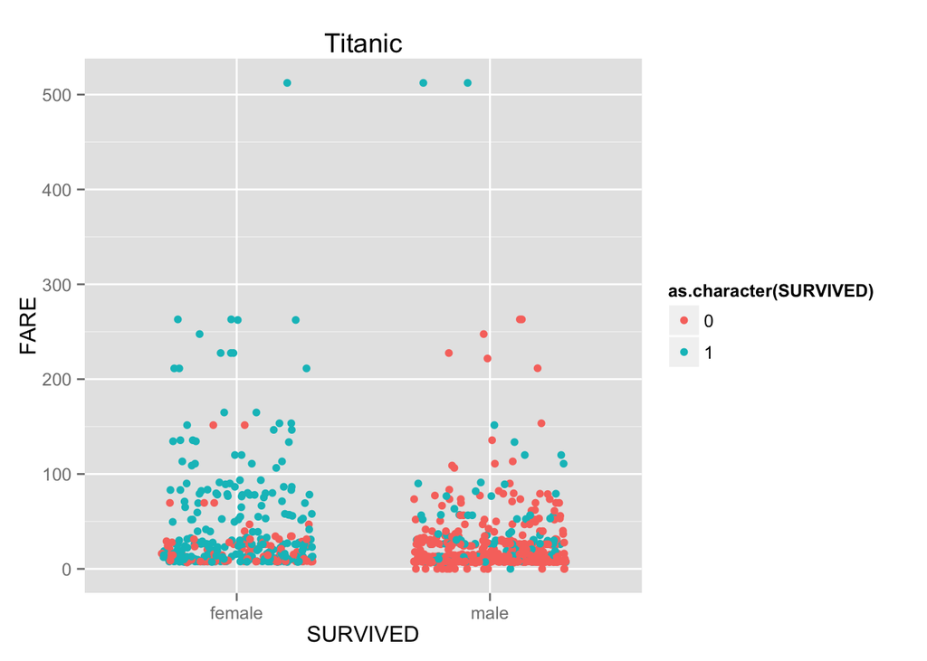

```r
source("../02 Visualizations/Graph 3.R", echo = TRUE)
```

### Graph 4

Graph four is similar to graph three but using the facet function it has divided the passengers by passenger class. This graph shows that hardly any wealthy women died in the sinking of the titanic, but the proportion of men dying does not change much by passenger class

```
##
## > require("jsonlite")
##
## > require("RCurl")
##
## > require("ggplot2")
##
## > df <- data.frame(fromJSON(getURL(URLencode("129.152.144.84:5001/rest/native/?query=\"select * from titanic where SEX is NOT NULL\""),
## +     httphea .... [TRUNCATED]
##
## > summary(df)
##   PASSENGERID       SURVIVED          PCLASS
##  Min.   :  1.0   Min.   :0.0000   Min.   :1.000
##  1st Qu.:223.5   1st Qu.:0.0000   1st Qu.:2.000
##  Median :446.0   Median :0.0000   Median :3.000
##  Mean   :446.0   Mean   :0.3838   Mean   :2.309
##  3rd Qu.:668.5   3rd Qu.:1.0000   3rd Qu.:3.000
##  Max.   :891.0   Max.   :1.0000   Max.   :3.000
##
##                                     NAME         SEX           AGE
##  Abbing, Mr. Anthony                  :  1   female:314   null   :177
##  Abbott, Mr. Rossmore Edward          :  1   male  :577   24     : 30
##  Abbott, Mrs. Stanton (Rosa Hunt)     :  1                22     : 27
##  Abelson, Mr. Samuel                  :  1                18     : 26
##  Abelson, Mrs. Samuel (Hannah Wizosky):  1                19     : 25
##  Adahl, Mr. Mauritz Nils Martin       :  1                28     : 25
##  (Other)                              :885                (Other):581
##      SIBSP           PARCH             TICKET         FARE
##  Min.   :0.000   Min.   :0.0000   1601    :  7   Min.   :  0.00
##  1st Qu.:0.000   1st Qu.:0.0000   347082  :  7   1st Qu.:  7.91
##  Median :0.000   Median :0.0000   CA. 2343:  7   Median : 14.45
##  Mean   :0.523   Mean   :0.3816   3101295 :  6   Mean   : 32.20
##  3rd Qu.:1.000   3rd Qu.:0.0000   347088  :  6   3rd Qu.: 31.00
##  Max.   :8.000   Max.   :6.0000   CA 2144 :  6   Max.   :512.33
##                                   (Other) :852
##          CABIN     EMBARKED
##  null       :687   C   :168
##  B96 B98    :  4   null:  2
##  C23 C25 C27:  4   Q   : 77
##  G6         :  4   S   :644
```

[output cut: 8 more lines]

```
## 3         313        0      2 Lahtinen, Mrs. William (Anna Sylfven) female
## 4         314        0      3                Hendekovic, Mr. Ignjac   male
## 5         315        0      2                    Hart, Mr. Benjamin   male
## 6         316        1      3       Nilsson, Miss. Helmina Josefina female
##   AGE SIBSP PARCH       TICKET     FARE           CABIN EMBARKED
## 1  24     0     0        11767  83.1583             C54        C
## 2  18     2     2     PC 17608 262.3750 B57 B59 B63 B66        C
## 3  26     1     1       250651  26.0000            null        S
## 4  28     0     0       349243   7.8958            null        S
## 5  43     1     1 F.C.C. 13529  26.2500            null        S
## 6  26     0     0       347470   7.8542            null        S
##
## > ggplot() + coord_cartesian() + scale_x_discrete() +
## +     scale_y_continuous() + facet_grid(PCLASS ~ SURVIVED, labeller = label_both) +
## +     labs .... [TRUNCATED]
```

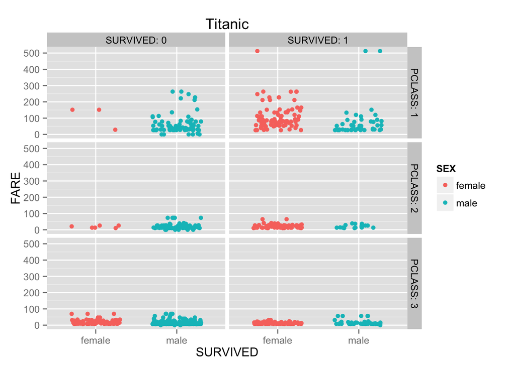

```r
source("../02 Visualizations/Graph 4.R", echo = TRUE)
```

### Graph 5

Graph 5 is the same as graph four but the sql statement is changed to only include data from passengers whose age is less than or equal to 10. This graph shows that hardly any children in the higher tiered passenger classes perished. Unlike with the adults, there is hardly a distinction between female and male survival rates.

```
##
## > require("jsonlite")
##
## > require("RCurl")
##
## > require("ggplot2")
##
## > df <- data.frame(fromJSON(getURL(URLencode("129.152.144.84:5001/rest/native/?query=\"select * from titanic where AGE <= 10\""),
## +     httpheader =  .... [TRUNCATED]
##
## > summary(df)
##   PASSENGERID       SURVIVED          PCLASS
##  Min.   :  8.0   Min.   :0.0000   Min.   :1.000
##  1st Qu.:183.8   1st Qu.:0.0000   1st Qu.:2.000
##  Median :414.0   Median :1.0000   Median :3.000
##  Mean   :430.8   Mean   :0.5938   Mean   :2.641
##  3rd Qu.:699.2   3rd Qu.:1.0000   3rd Qu.:3.000
##  Max.   :870.0   Max.   :1.0000   Max.   :3.000
##
##                                       NAME        SEX          AGE
##  Allison, Master. Hudson Trevor         : 1   female:31   Min.   : 0.420
##  Allison, Miss. Helen Loraine           : 1   male  :33   1st Qu.: 2.000
##  Andersson, Master. Sigvard Harald Elias: 1               Median : 4.000
##  Andersson, Miss. Ebba Iris Alfrida     : 1               Mean   : 4.268
##  Andersson, Miss. Ellis Anna Maria      : 1               3rd Qu.: 7.000
##  Andersson, Miss. Ingeborg Constanzia   : 1               Max.   :10.000
##  (Other)                                :58
##      SIBSP           PARCH           TICKET        FARE
##  Min.   :0.000   Min.   :0.000   347082 : 4   Min.   :  8.517
##  1st Qu.:0.750   1st Qu.:1.000   347088 : 4   1st Qu.: 19.131
##  Median :1.000   Median :1.000   382652 : 4   Median : 27.000
##  Mean   :1.844   Mean   :1.422   2666   : 3   Mean   : 30.434
##  3rd Qu.:3.250   3rd Qu.:2.000   3101295: 3   3rd Qu.: 31.387
##  Max.   :5.000   Max.   :2.000   347077 : 3   Max.   :151.550
##                                  (Other):43
##      CABIN    EMBARKED
##  A34    : 1   C: 9
##  C22 C26: 2   Q: 4
##  E121   : 1   S:51
##  F2     : 2
```

[output cut: 8 more lines]

```
## 3         375        0      3           Palsson, Miss. Stina Viola female
## 4         382        1      3            Nakid, Miss. Maria (Mary) female
## 5         387        0      3      Goodwin, Master. Sidney Leonard   male
## 6         408        1      2       Richards, Master. William Rowe   male
##   AGE SIBSP PARCH     TICKET    FARE CABIN EMBARKED
## 1   2     1     1     230080 26.0000    F2        S
## 2   3     1     1 C.A. 37671 15.9000  null        S
## 3   3     3     1     349909 21.0750  null        S
## 4   1     0     2       2653 15.7417  null        C
## 5   1     5     2    CA 2144 46.9000  null        S
## 6   3     1     1      29106 18.7500  null        S
##
## > ggplot() + coord_cartesian() + scale_x_discrete() +
## +     scale_y_continuous() + facet_grid(PCLASS ~ SURVIVED, labeller = label_both) +
## +     labs .... [TRUNCATED]
```

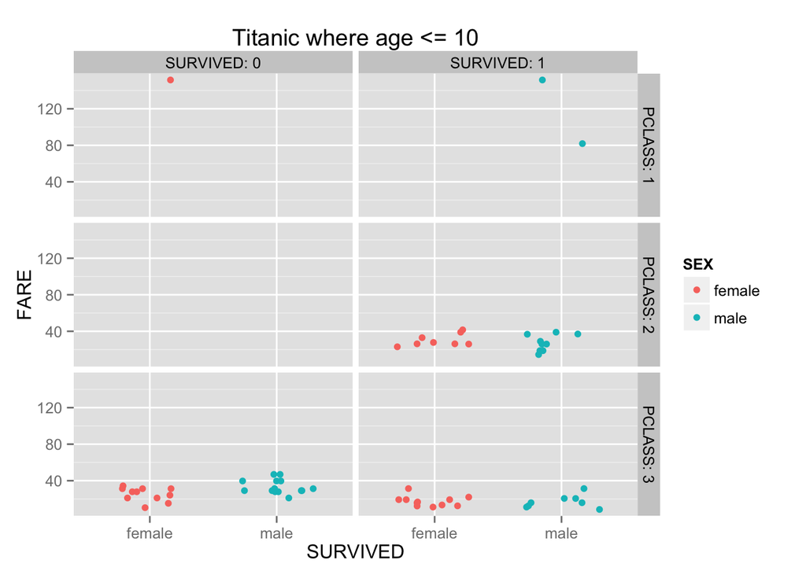

```r
source("../02 Visualizations/Graph 5.R", echo = TRUE)
```

### Custom Graph

In my custom graph, I wanted to know the relationship between age and survival rate. For men over the age of 20, the surivaval rate drastically decreases, whereas for women the rate remains relativly even no matter the age. To make this graph, I used facetwrap for SEX to create distinct plots based on gender. I also changed the x axis to age.

```
##
## > require("jsonlite")
##
## > require("RCurl")
##
## > require("ggplot2")
##
## > df <- data.frame(fromJSON(getURL(URLencode("129.152.144.84:5001/rest/native/?query=\"select * from titanic where SURVIVED is NOT NULL \""),
## +     h .... [TRUNCATED]
##
## > summary(df)
##   PASSENGERID       SURVIVED          PCLASS
##  Min.   :  1.0   Min.   :0.0000   Min.   :1.000
##  1st Qu.:223.5   1st Qu.:0.0000   1st Qu.:2.000
##  Median :446.0   Median :0.0000   Median :3.000
##  Mean   :446.0   Mean   :0.3838   Mean   :2.309
##  3rd Qu.:668.5   3rd Qu.:1.0000   3rd Qu.:3.000
##  Max.   :891.0   Max.   :1.0000   Max.   :3.000
##
##                                     NAME         SEX           AGE
##  Abbing, Mr. Anthony                  :  1   female:314   null   :177
##  Abbott, Mr. Rossmore Edward          :  1   male  :577   24     : 30
##  Abbott, Mrs. Stanton (Rosa Hunt)     :  1                22     : 27
##  Abelson, Mr. Samuel                  :  1                18     : 26
##  Abelson, Mrs. Samuel (Hannah Wizosky):  1                19     : 25
##  Adahl, Mr. Mauritz Nils Martin       :  1                28     : 25
##  (Other)                              :885                (Other):581
##      SIBSP           PARCH             TICKET         FARE
##  Min.   :0.000   Min.   :0.0000   1601    :  7   Min.   :  0.00
##  1st Qu.:0.000   1st Qu.:0.0000   347082  :  7   1st Qu.:  7.91
##  Median :0.000   Median :0.0000   CA. 2343:  7   Median : 14.45
##  Mean   :0.523   Mean   :0.3816   3101295 :  6   Mean   : 32.20
##  3rd Qu.:1.000   3rd Qu.:0.0000   347088  :  6   3rd Qu.: 31.00
##  Max.   :8.000   Max.   :6.0000   CA 2144 :  6   Max.   :512.33
##                                   (Other) :852
##          CABIN     EMBARKED
##  null       :687   C   :168
##  B96 B98    :  4   null:  2
##  C23 C25 C27:  4   Q   : 77
##  G6         :  4   S   :644
```

[output cut: 9 more lines]

```
## 4         314        0      3                Hendekovic, Mr. Ignjac   male
## 5         315        0      2                    Hart, Mr. Benjamin   male
## 6         316        1      3       Nilsson, Miss. Helmina Josefina female
##   AGE SIBSP PARCH       TICKET     FARE           CABIN EMBARKED
## 1  24     0     0        11767  83.1583             C54        C
## 2  18     2     2     PC 17608 262.3750 B57 B59 B63 B66        C
## 3  26     1     1       250651  26.0000            null        S
## 4  28     0     0       349243   7.8958            null        S
## 5  43     1     1 F.C.C. 13529  26.2500            null        S
## 6  26     0     0       347470   7.8542            null        S
##
## > require(extrafont)
##
## > ggplot() + coord_cartesian() + scale_x_continuous() +
## +     scale_y_continuous() + facet_wrap(~SEX) + labs(title = "Titanic Survivors Based on Age  ..." ... [TRUNCATED]
```

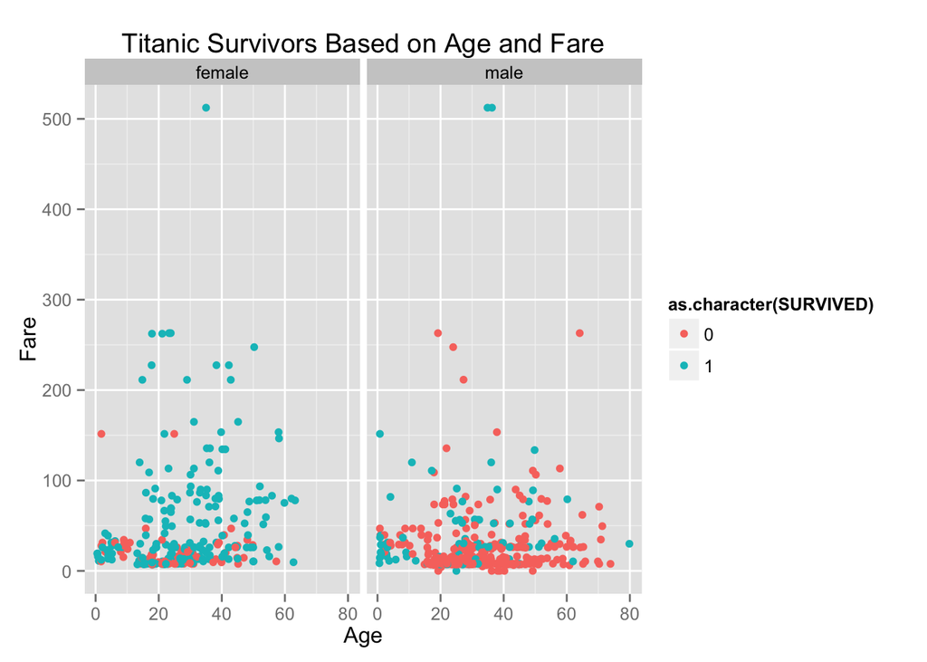

```r
source("../02 Visualizations/Custom Graph.R", echo = TRUE)
```